# Final Project

STAT 420, Summer 2020, Mandalorians

```r
library("tibble")
library("readr")
library("Hmisc")
library("dplyr")
library("statsr")
library("GGally")
library("gridExtra")
library("MASS")
library("faraway")
library("lmtest")
library("stringr")
```

# Introduction

We have a housing dataset. We have pulled this dataset as part of a kaggle challenge. We have the train and test data as separate files. Since this is a challenge, we dont have the predicted values for the test dataset.

Our job is to predict house prices, given 80 predictors.

We can see the structure of the dataset below

```r
df1 <-read.csv("train.csv",as.is = FALSE )

str(df1)
```

```
## 'data.frame':    1460 obs. of  81 variables:
##  $ Id           : int  1 2 3 4 5 6 7 8 9 10 ...
##  $ MSSubClass   : int  60 20 60 70 60 50 20 60 50 190 ...
##  $ MSZoning     : Factor w/ 5 levels "C (all)","FV",..: 4 4 4 4 4 4 4 4 5 4 ...
##  $ LotFrontage  : int  65 80 68 60 84 85 75 NA 51 50 ...
##  $ LotArea      : int  8450 9600 11250 9550 14260 14115 10084 10382 6120 7420 ...
##  $ Street       : Factor w/ 2 levels "Grvl","Pave": 2 2 2 2 2 2 2 2 2 2 ...
##  $ Alley        : Factor w/ 2 levels "Grvl","Pave": NA NA NA NA NA NA NA NA NA NA ...
##  $ LotShape     : Factor w/ 4 levels "IR1","IR2","IR3",..: 4 4 1 1 1 1 4 1 4 4 ...
##  $ LandContour  : Factor w/ 4 levels "Bnk","HLS","Low",..: 4 4 4 4 4 4 4 4 4 4 ...
##  $ Utilities    : Factor w/ 2 levels "AllPub","NoSeWa": 1 1 1 1 1 1 1 1 1 1 ...
##  $ LotConfig    : Factor w/ 5 levels "Corner","CulDSac",..: 5 3 5 1 3 5 5 1 5 1 ...
##  $ LandSlope    : Factor w/ 3 levels "Gtl","Mod","Sev": 1 1 1 1 1 1 1 1 1 1 ...
##  $ Neighborhood : Factor w/ 25 levels "Blmngtn","Blueste",..: 6 25 6 7 14 12 21 17 18 4 ...
##  $ Condition1   : Factor w/ 9 levels "Artery","Feedr",..: 3 2 3 3 3 3 3 5 1 1 ...
```

[output cut: 67 more lines]

Now we investigate the dataset to see what actions we need to take with the dataset before creating a model

Since the output is very long, we use echo=FALSE, but as a sample, we show the output below for the first 5 rows

```r
Hmisc::html(Hmisc::describe(df1[,1:5]), where=c('cwd', 'tmp'))
```

df1[, 1:5]  
5 Variables 1460 Observations

Id

```
        n  missing distinct     Info     Mean      Gmd      .05      .10      .25
     1460        0     1460        1    730.5      487    73.95   146.90   365.75
      .50      .75      .90      .95
   730.50  1095.25  1314.10  1387.05
```

lowest : 1 2 3 4 5 , highest: 1456 1457 1458 1459 1460

MSSubClass

| n | missing | distinct | Info | Mean | Gmd | .05 | .10 | .25 | .50 | .75 | .90 | .95 |
| --- | --- | --- | --- | --- | --- | --- | --- | --- | --- | --- | --- | --- |
| 1460 | 0 | 15 | 0.94 | 56.9 | 43.19 | 20 | 20 | 20 | 50 | 70 | 120 | 160 |

lowest : 20 30 40 45 50 , highest: 90 120 160 180 190

```
 Value         20    30    40    45    50    60    70    75    80    85    90   120
 Frequency    536    69     4    12   144   299    60    16    58    20    52    87
 Proportion 0.367 0.047 0.003 0.008 0.099 0.205 0.041 0.011 0.040 0.014 0.036 0.060

 Value        160   180   190
 Frequency     63    10    30
 Proportion 0.043 0.007 0.021
```

MSZoning

| n | missing | distinct |
| --- | --- | --- |
| 1460 | 0 | 5 |

lowest : C (all) FV RH RL RM , highest: C (all) FV RH RL RM

```
 Value      C (all)      FV      RH      RL      RM
 Frequency       10      65      16    1151     218
 Proportion   0.007   0.045   0.011   0.788   0.149
```

LotFrontage

| n | missing | distinct | Info | Mean | Gmd | .05 | .10 | .25 | .50 | .75 | .90 | .95 |
| --- | --- | --- | --- | --- | --- | --- | --- | --- | --- | --- | --- | --- |
| 1201 | 259 | 110 | 0.998 | 70.05 | 24.61 | 34 | 44 | 59 | 69 | 80 | 96 | 107 |

lowest : 21 24 30 32 33 , highest: 160 168 174 182 313

LotArea

| n | missing | distinct | Info | Mean | Gmd | .05 | .10 | .25 | .50 | .75 | .90 | .95 |
| --- | --- | --- | --- | --- | --- | --- | --- | --- | --- | --- | --- | --- |
| 1460 | 0 | 1073 | 1 | 10517 | 5718 | 3312 | 5000 | 7554 | 9478 | 11602 | 14382 | 17401 |

lowest : 1300 1477 1491 1526 1533 , highest: 70761 115149 159000 164660 215245

We have 80 predictors in the dataset. That tells us that we really arent short of predictors.

Based on the above dataset description (showing only first 5 for brevity) we draw the following conclusions

**Remove these columns**

- Remove Id column since it is not a predictor and is simply a running id
- Alley - has 1369 missing values and only 91 observations with values.
- Street - Only 6 elements or 0.4% data elements have Street as Grvl, rest are all Pave. 6 is too few data elements to make a prediction
- LotFrontage has 259 missing values. This is about 18% of total observations. If we were short of predictors we would not delete it. Since there a lot of predictors that convey space of the house, we will delete this column
- Utilities - Only 1 value has NoSeWa and the rest are all AllPub. Since only 1 element isnt enough for creating a model
- Condition2 - remove since 99% are Norm while the remaining 1% are distributed across 7 other values. This implies that the other 7 values dont have enough data to make a useful prediction
- RoofMatl - 98.2% is CompShg and the remaining 1.8% is spread across 7 values and the remaining 7 values dont have enough data to make a prediction
- X3SsnPorch - 98.4% is value 0, and the remaining 1.6% is spread across 19 types. Each of these has only 1 or 2 observtions hence not enough data for prediction
- PoolArea - 99.5% has value 0 and the remaining .5% is apread across 7 factors, implying not enough data in each type to make a model
- PoolQC - since only 7 observations have non missing values
- MiscFeature, MiscVal - since only 54 and 52 observations respectively have values
- FirePlaceQu - has 690 values missing which is approximately 47% of total predictors. Since we are not short of number of predictors, and this one has half the values missing, we will delete this predictor
- Fence - 1179 values missing.

**Other Observations**

- MasVnrType and MasVnrArea - has 8 missing values
- BsmtQual, BsmtCond, BsmtExposure, BsmtFinType1, BsmtFinType2 - each have 37 or 38 missing values
- Electrical = has 1 value missing
- GarageType, GarageYrBlt, GarageFinish, GarageQual, GarageCond - has 81 values missing

Based on the above analysis we remove the ones that we want to remove and store the column names for the ones with missing values in a vector to be used later if necessary

```r
remove_cols <- c("Id", "Alley", "Street", "LotFrontage", "Utilities", "Condition2", "RoofMatl", "X3SsnPorch", "PoolArea", "PoolQC", "MiscFeature", "MiscVal", "FireplaceQu", "Fence")

col_with_missing_values <- c("MasVnrType", "MasVnrArea", "BsmtQual", "BsmtCond", "BsmtExposure", "BsmtFinType1", "BsmtFinType2", "Electrical", "GarageType", "GarageYrBlt", "GarageFinish", "GarageQual", "GarageCond")

keep_cols <- colnames(df1)[!(colnames(df1) %in% remove_cols)]

df_cols_removed <- subset(df1, select = as.vector(eval(keep_cols)))
```

In order to identify correlation we first create a dataframe that has only numeric predictors

```r
df_only_numeric <- df_cols_removed[,sapply(df_cols_removed, is.numeric)]
```

Now we identify the correlation in numeric predictors. We mark all correlations less than .75 as NA, so that we can easily identify highly corelated features

```r
cor_relation = cor(df_only_numeric, use = "complete.obs")
cor_relation[abs(cor_relation) < 0.75] <- NA
cor_relation
```

```
##               MSSubClass LotArea OverallQual OverallCond YearBuilt YearRemodAdd
## MSSubClass             1      NA          NA          NA        NA           NA
## LotArea               NA       1          NA          NA        NA           NA
## OverallQual           NA      NA   1.0000000          NA        NA           NA
## OverallCond           NA      NA          NA           1        NA           NA
## YearBuilt             NA      NA          NA          NA 1.0000000           NA
## YearRemodAdd          NA      NA          NA          NA        NA            1
## MasVnrArea            NA      NA          NA          NA        NA           NA
## BsmtFinSF1            NA      NA          NA          NA        NA           NA
## BsmtFinSF2            NA      NA          NA          NA        NA           NA
## BsmtUnfSF             NA      NA          NA          NA        NA           NA
## TotalBsmtSF           NA      NA          NA          NA        NA           NA
## X1stFlrSF             NA      NA          NA          NA        NA           NA
## X2ndFlrSF             NA      NA          NA          NA        NA           NA
## LowQualFinSF          NA      NA          NA          NA        NA           NA
## GrLivArea             NA      NA          NA          NA        NA           NA
## BsmtFullBath          NA      NA          NA          NA        NA           NA
## BsmtHalfBath          NA      NA          NA          NA        NA           NA
## FullBath              NA      NA          NA          NA        NA           NA
## HalfBath              NA      NA          NA          NA        NA           NA
## BedroomAbvGr          NA      NA          NA          NA        NA           NA
## KitchenAbvGr          NA      NA          NA          NA        NA           NA
## TotRmsAbvGrd          NA      NA          NA          NA        NA           NA
## Fireplaces            NA      NA          NA          NA        NA           NA
## GarageYrBlt           NA      NA          NA          NA 0.8246693           NA
## GarageCars            NA      NA          NA          NA        NA           NA
## GarageArea            NA      NA          NA          NA        NA           NA
## WoodDeckSF            NA      NA          NA          NA        NA           NA
## OpenPorchSF           NA      NA          NA          NA        NA           NA
## EnclosedPorch         NA      NA          NA          NA        NA           NA
## ScreenPorch           NA      NA          NA          NA        NA           NA
## MoSold                NA      NA          NA          NA        NA           NA
## YrSold                NA      NA          NA          NA        NA           NA
## SalePrice             NA      NA   0.7862117          NA        NA           NA
##               MasVnrArea BsmtFinSF1 BsmtFinSF2 BsmtUnfSF TotalBsmtSF X1stFlrSF
## MSSubClass            NA         NA         NA        NA          NA        NA
## LotArea               NA         NA         NA        NA          NA        NA
## OverallQual           NA         NA         NA        NA          NA        NA
## OverallCond           NA         NA         NA        NA          NA        NA
## YearBuilt             NA         NA         NA        NA          NA        NA
```

[output cut: 149 more lines]

```
## HalfBath               NA            NA          NA     NA     NA        NA
## BedroomAbvGr           NA            NA          NA     NA     NA        NA
## KitchenAbvGr           NA            NA          NA     NA     NA        NA
## TotRmsAbvGrd           NA            NA          NA     NA     NA        NA
## Fireplaces             NA            NA          NA     NA     NA        NA
## GarageYrBlt            NA            NA          NA     NA     NA        NA
## GarageCars             NA            NA          NA     NA     NA        NA
## GarageArea             NA            NA          NA     NA     NA        NA
## WoodDeckSF             NA            NA          NA     NA     NA        NA
## OpenPorchSF             1            NA          NA     NA     NA        NA
## EnclosedPorch          NA             1          NA     NA     NA        NA
## ScreenPorch            NA            NA           1     NA     NA        NA
## MoSold                 NA            NA          NA      1     NA        NA
## YrSold                 NA            NA          NA     NA      1        NA
## SalePrice              NA            NA          NA     NA     NA 1.0000000
```

Based on the above correlation matrix, we make the below observations

**Remove the following predictors**

- YearBuilt and GarageYrBlt has .82 correlation coefficient. This makes sense since the Garage will be built in the same year as the house, with a few exceptions. We also reason that the price will be more tied to how old the house is. Since YearBuilt of house will be a more useful predictor, we will remove GarageYrBlt
- X1stFlrSF and TotalBsmtSF has a .82 correlation. This is obvious since the size of teh 1st floor will be very similar to size of basement. We can also reason that the price will be more correlated to the price of the 1st floor. Hence we will remove TotalBsmtSF
- GarageArea and GarageCars have a .83 correlation. Intutively we can see that both of these are related. Hence we remove GarageCars
- GrLivArea and TotRmsAbvGrd has a correlation of .82. We see that number of Bedrooms and kitchens and batrooms are already captured separately. Hence we remove TotRmsAbvGrd

**Make a note of these** * OverallQual has a .78 correlation with SalePrice. Given that, we should make sure OverallQual is part of the model

```r
remove_cols2 <- c("GarageYrBlt", "TotalBsmtSF", "GarageCars", "TotRmsAbvGrd")

keep_cols2 <- colnames(df_cols_removed)[!(colnames(df_cols_removed) %in% remove_cols2)]

df_cols_removed <- subset(df_cols_removed, select = as.vector(eval(keep_cols2)))

ncol(df_cols_removed)
```

```
## [1] 63
```

We see that now we are left with 63 columns compared to the 81 that we started with.

We know that step wont work with missing values. Hence we will need to remove those.

```r
df_cols_removed <- na.omit(df_cols_removed)
nrow(df_cols_removed)
```

```
## [1] 1338
```

We started with 1460 observations and 81 columns and after our initial cleanup we end up with 1338 observations and 63 columns

Now, before we begin modeling, we look at the pairs plots to see if any of the parameters are an obvious choice for transformations

For the purpose of being able to see the plots clearly, we do two things for the visual of the pair plot

We wont save this intermim dataset. It is only created to be able to see the distribution across many predictors clearly

```r
df_only_numeric <- df_cols_removed[,sapply(df_cols_removed, is.numeric)]
remove_for_plot <- c()
j=1
for(i in colnames(df_only_numeric)){
  k <- length(unique(df_only_numeric[,i])<20)
  if(k<20){
    remove_for_plot[j] <- i
    j <- j+1
  }
}

keep_for_plot <- colnames(df_only_numeric)[!(colnames(df_only_numeric) %in% remove_for_plot)]

df_cols_removed_for_plot <- subset(df_only_numeric, select = as.vector(eval(keep_for_plot)))
```

```r
#pairs(df_only_numeric)
ggpairs( df_cols_removed_for_plot, ggplot2::aes(color=I("navyblue")), title = "ggpairs plot to see correlation and distribution", lower = list(continuous = wrap("smooth")), axisLabels = "show", switch = "both")
```

[figure not shown]

We make the following observations from the plot

** Potential for transformations **

- LotArea
- MasVnrArea
- BsmtFinSF1
- BsmtFinSF2
- X1stFlrSF
- GrLivArea
- GarageArea
- WoodDeckSF
- OpenPorchSF
- EnclosedPorch
- YearBuilt
- YearRemodAdd
- SalePrice

In order to validate that transformations are necessary we will start with a simple additive model and look at its diagnostics plots

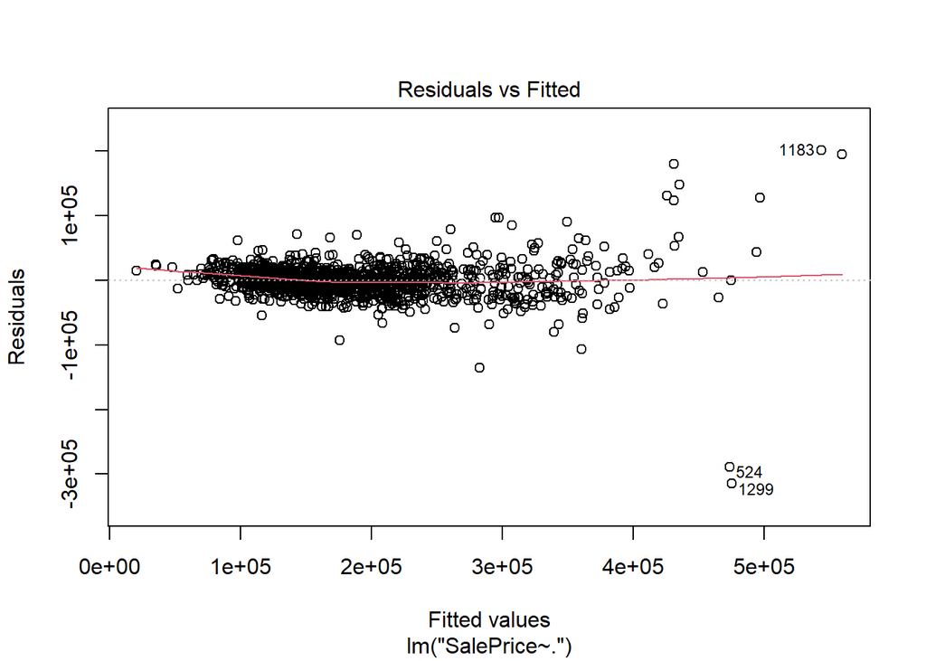

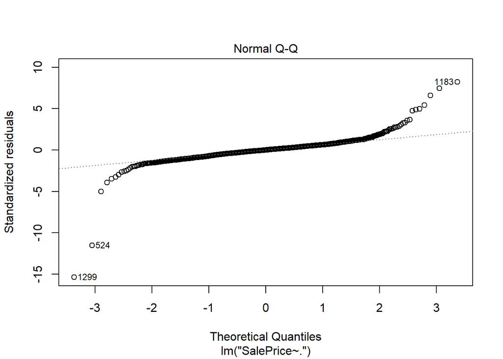

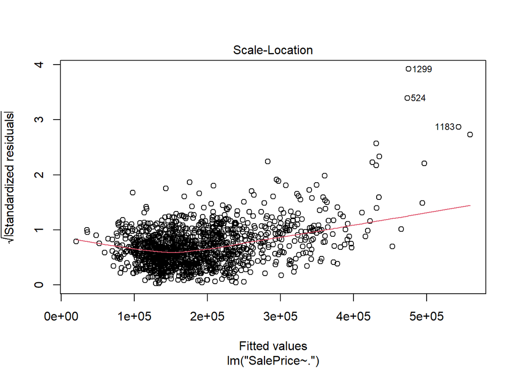

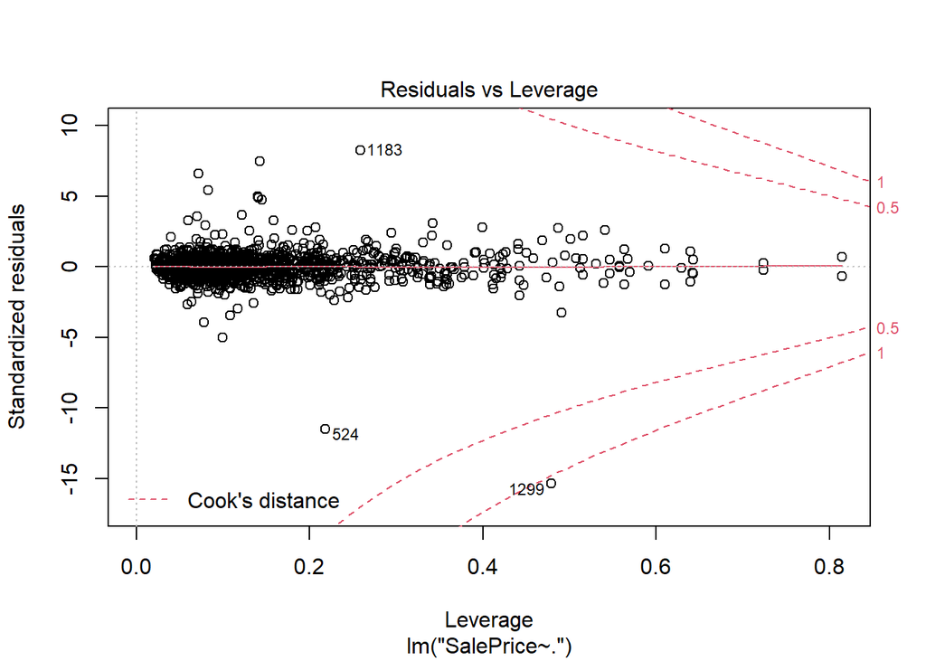

```r
m1 <- lm("SalePrice~.", data=df_cols_removed)
plot(m1)
```

Based on the diagnostics plot we see that some kind of transformation for the response is necessary.

In order to figure out the transformation we find the lambda for it

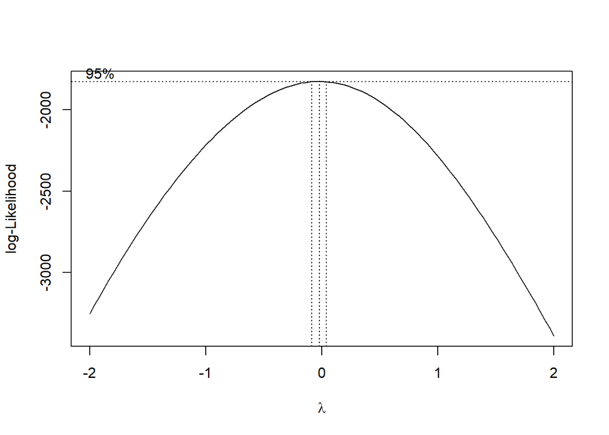

```r
boxcox(m1)
```

We know that the most common Box-Cox Transformations are

| $\lambda$ | Tranasformed Data |
| --- | --- |
| -2 | $y^{-2}$ |
| -1 | $y^{-1}$ |
| -.5 | $1 \over \sqrt y$ |
| 0 | ln(y) |
| .5 | $\sqrt y$ |
| 1 | y |
| 2 | $y^2$ |

since our $\lambda$ is close to 0 we will do log transformations

We redo the model and look at the diagnostics plots again

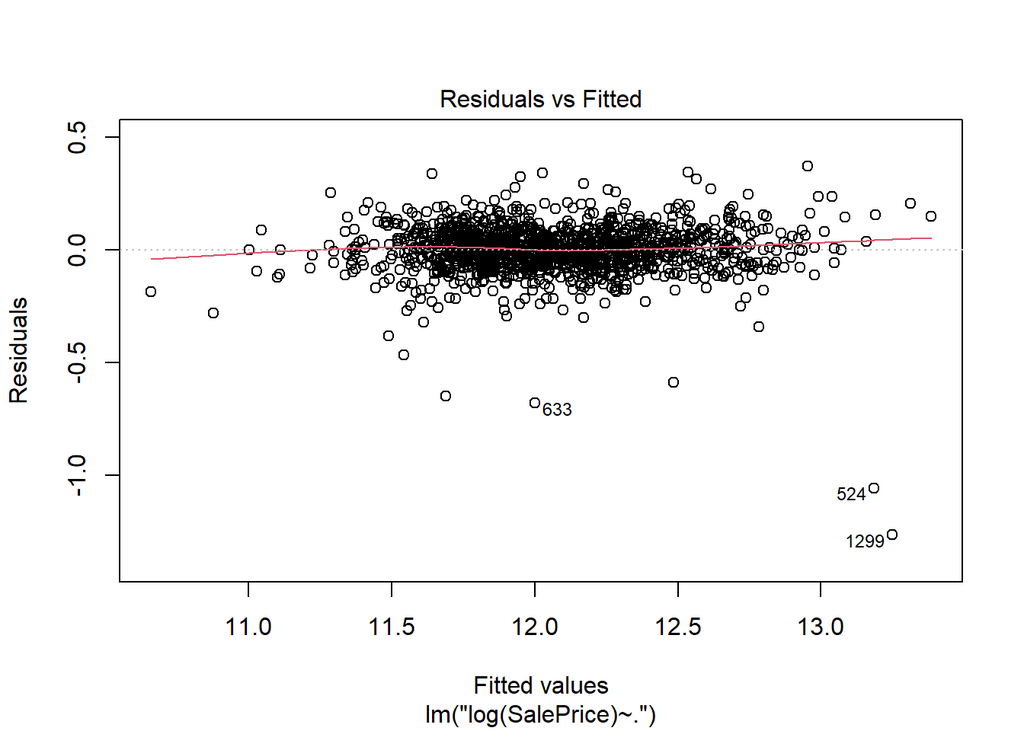

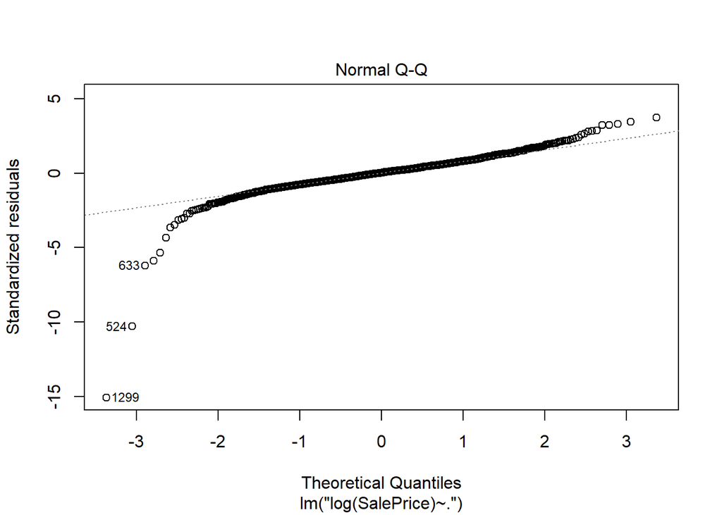

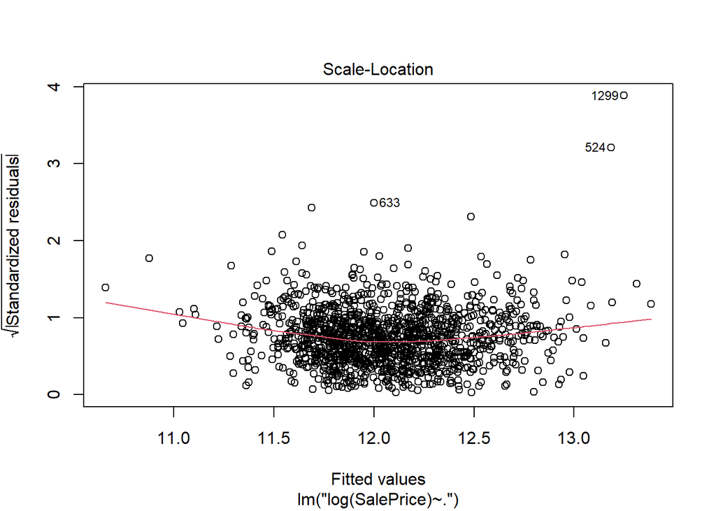

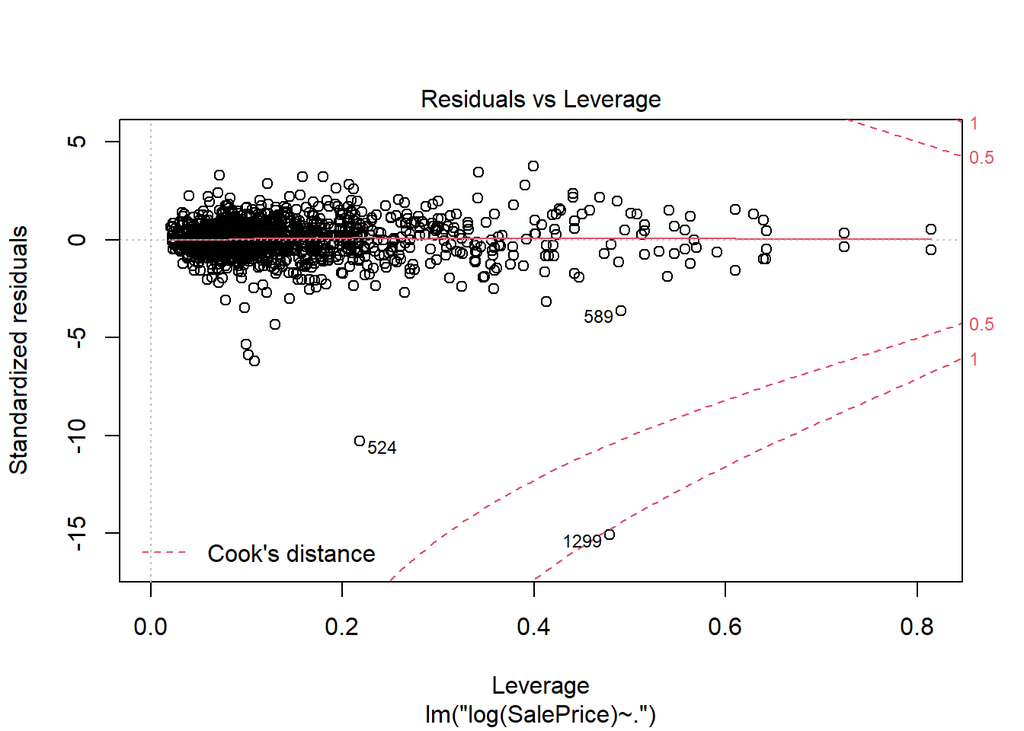

```r
m2 <- lm("log(SalePrice)~.", data=df_cols_removed)
plot(m2)
```

We see that the plots are a lot better, but there seems to be some scope for improvement.

Let us now identify the lamda transformations for the other columns we identified and using those variables as response, fit the model, but keep log(SalePrice) in the predictor with others

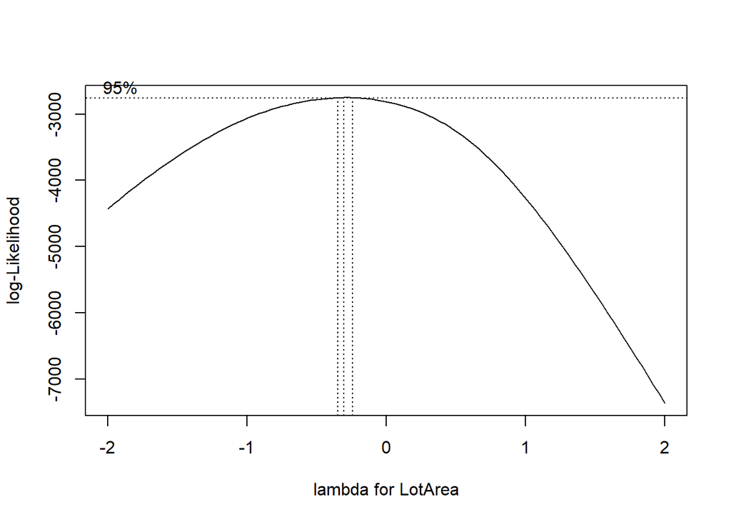

```r
m3 <- lm("LotArea~.-SalePrice+log(SalePrice)", data = df_cols_removed)
boxcox(m3,xlab = "lambda for LotArea")
```

We should apply log transformation to LotArea since $\lambda$ is close to 0

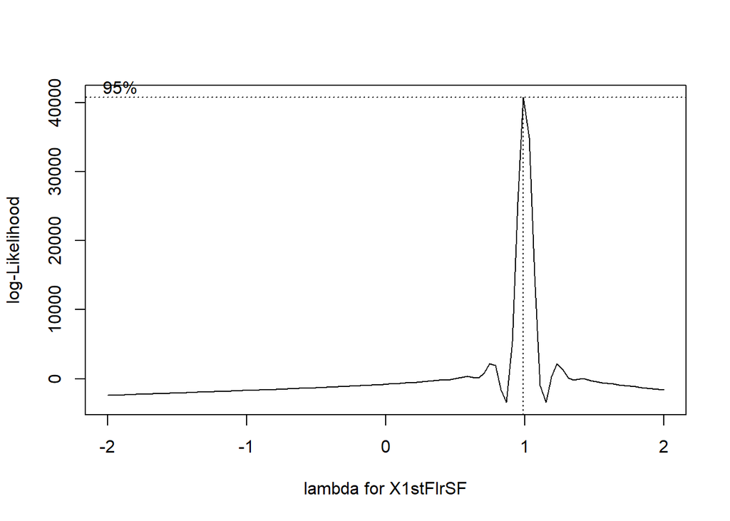

```r
m3 <- lm("X1stFlrSF~.-SalePrice+log(SalePrice)", data = df_cols_removed)
boxcox(m3,xlab = "lambda for X1stFlrSF")
```

There is no need to apply any transformation to X1stFlrSF

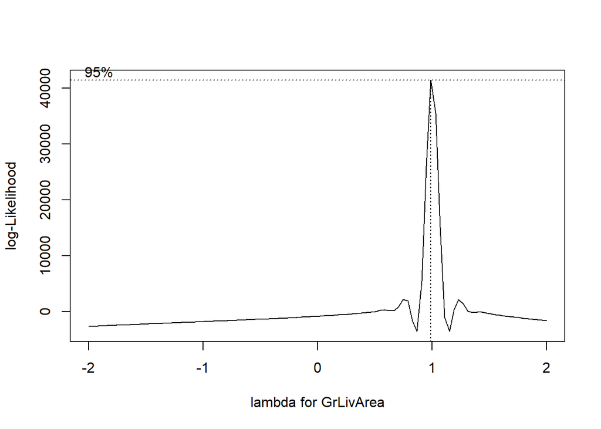

```r
m3 <- lm("GrLivArea~.-SalePrice+log(SalePrice)", data = df_cols_removed)
boxcox(m3,xlab = "lambda for GrLivArea")
```

There is no need to apply any transformation to GrLivArea

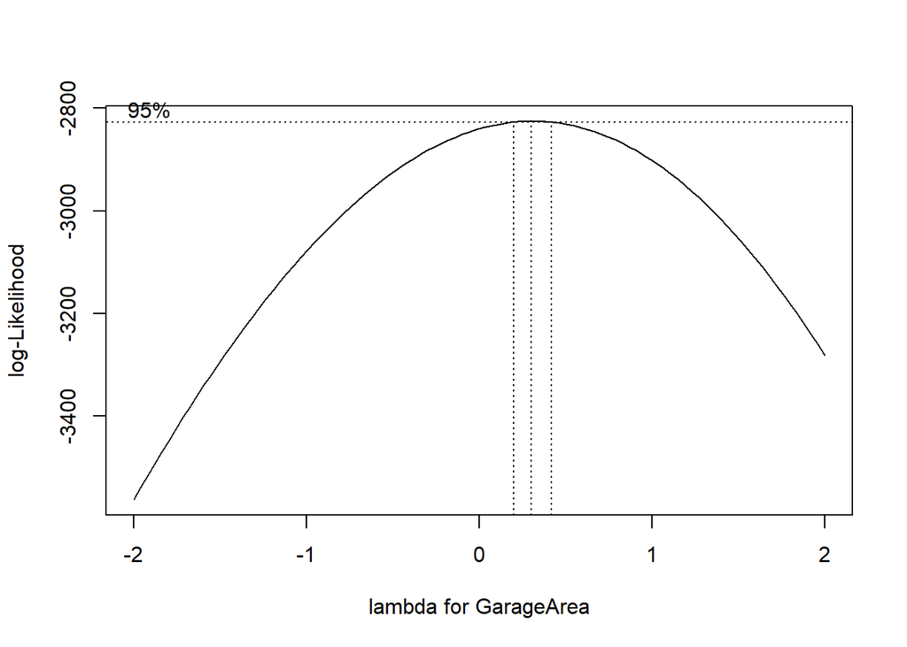

```r
m3 <- lm("GarageArea~.-SalePrice+log(SalePrice)", data = df_cols_removed)
boxcox(m3,xlab = "lambda for GarageArea")
```

```r
m3 <- lm("YearBuilt~.-SalePrice+log(SalePrice)", data = df_cols_removed)
bc <- boxcox(m3,xlab = "lambda for YearBuilt", lambda = seq(-200,400))
```

[figure not shown]

```r
(best_lam <- bc$x[which(bc$y==max(bc$y))])
```

```
## [1] 37
```

```r
m3 <- lm("YearRemodAdd~.-SalePrice+log(SalePrice)", data = df_cols_removed)
bc <- boxcox(m3,xlab = "lambda for YearRemodAdd", lambda = seq(-200,400))
```

[figure not shown]

```r
(best_lam <- bc$x[which(bc$y==max(bc$y))])
```

```
## [1] 57
```

YearBuilt and YearRemodAdd have very high $\lambda$ and using these transformations will make it very hard to explain the model. We will keep a note of these two, and experiment with them if necessary

We will not identify the Lambda for MasVnrArea, BsmtFinSF1, BsmtFinSF2, WoodDeckSF, OpenPorchSF, EnclosedPorch since those predictors contant 0’s, and we cant run the boxcox funtion on them unless we handle the 0’s. Since we have a lot of predictors, we will not message these 6 predictors.

Based on the above analysis we create 2 models to start with

1. A simple additive model
2. A model with the above transformations but without the extreme transformations for YearBuilt and YearRemodAdd

```r
create_formula <- function(data_set, response, cols_to_remove="", cols_to_add=""){

  predictor_list <- colnames(df_cols_removed)

  predictor_list <- predictor_list[!(predictor_list %in% cols_to_remove)]
  n <- length(predictor_list)

  for(i in 1:length(cols_to_add)){
    n <- n+1
    predictor_list[n] <- cols_to_add[i]
  }

  frm1 <- paste(response, " ~ ", paste(predictor_list, collapse = ' + '))
}
```

```r
num_predictors_in_formula <- function(model_formula){

  return(length(strsplit(as.character(model_formula)[3], fixed = TRUE, split = "+")[[1]]))
}
```

```r
m_additive <- lm("SalePrice~.", data = df_cols_removed)
```

```r
frm <- create_formula(df_cols_removed, "log(SalePrice)", c("SalePrice", "LotArea", "GarageArea"), c("log(LotArea)", "log(GarageArea)"))

m_transform_1 <- lm(formula = frm, data = df_cols_removed)
```

```r
frm <- create_formula(df_cols_removed, "log(SalePrice)", c("SalePrice", "LotArea", "GarageArea", "YearBuilt", "YearRemodAdd"), c("log(LotArea)", "log(GarageArea)", "YearBuilt^35", "YearRemodAdd^55"))

m_transform_2 <- lm(formula = frm, data = df_cols_removed)
```

Now we use step backwards with aic for all 2 models above to find 2 good models which are smaller than the above

```r
m_additive_step <- step(m_additive, trace = 0)
(frm <- formula(m_additive_step))
```

```
## SalePrice ~ MSSubClass + MSZoning + LotArea + LotShape + LandContour +
##     LotConfig + LandSlope + Neighborhood + Condition1 + BldgType +
##     HouseStyle + OverallQual + OverallCond + YearBuilt + Exterior1st +
##     MasVnrArea + ExterQual + BsmtQual + BsmtExposure + BsmtFinType1 +
##     X1stFlrSF + X2ndFlrSF + LowQualFinSF + BsmtFullBath + FullBath +
##     HalfBath + KitchenAbvGr + KitchenQual + Functional + Fireplaces +
##     GarageArea + GarageQual + GarageCond + WoodDeckSF + OpenPorchSF +
##     ScreenPorch + SaleCondition
## <environment: 0x0000000028c43718>
```

```r
m_transform_1_step <- step(m_transform_1, trace = 0)
(frm <- formula(m_transform_1_step))
```

```
## log(SalePrice) ~ MSSubClass + MSZoning + LotShape + LandContour +
##     LotConfig + LandSlope + Neighborhood + Condition1 + OverallQual +
##     OverallCond + YearBuilt + YearRemodAdd + Exterior1st + ExterCond +
##     Foundation + BsmtQual + BsmtExposure + BsmtFinType1 + Heating +
##     HeatingQC + CentralAir + X1stFlrSF + X2ndFlrSF + BsmtFullBath +
##     FullBath + HalfBath + BedroomAbvGr + KitchenAbvGr + KitchenQual +
##     Functional + Fireplaces + GarageQual + GarageCond + PavedDrive +
##     WoodDeckSF + EnclosedPorch + ScreenPorch + SaleType + SaleCondition +
##     log(LotArea) + log(GarageArea)
## <environment: 0x000000001ffb7088>
```

By using AIC to step backwards we are not penalizing the models for the number of predictors. Since the models are still huge, we will run step BIC backwards on the results of the step AIC with the hope of getting smaller models

```r
m_additive_step_bic <- step(m_additive_step, trace = 0, k=log(nrow(df_cols_removed)))
(frm <- formula(m_additive_step_bic))
```

```
## SalePrice ~ MSSubClass + LotArea + Neighborhood + OverallQual +
##     OverallCond + YearBuilt + BsmtQual + BsmtExposure + X1stFlrSF +
##     X2ndFlrSF + BsmtFullBath + FullBath + KitchenQual + Fireplaces +
##     GarageArea + ScreenPorch
## <environment: 0x0000000028c43718>
```

```r
m_transform_1_step_bic <- step(m_transform_1_step, trace = 0, k=log(nrow(df_cols_removed)))
(frm <- formula(m_transform_1_step_bic))
```

```
## log(SalePrice) ~ MSSubClass + MSZoning + Neighborhood + OverallQual +
##     OverallCond + YearBuilt + YearRemodAdd + BsmtQual + CentralAir +
##     X1stFlrSF + X2ndFlrSF + BsmtFullBath + FullBath + Fireplaces +
##     WoodDeckSF + ScreenPorch + log(LotArea) + log(GarageArea)
## <environment: 0x000000001ffb7088>
```

```r
num_predictors_in_formula(frm)
```

```
## [1] 18
```

```r
diagnostics <- function(model = fit_1, pcol = 'dodgerblue', lcol = 'red', alpha = .05, plotit = TRUE, testit = TRUE){

  if(plotit == TRUE){
    g1 <- ggplot(data = model, aes(sample=.resid)) +
      stat_qq(color=I(pcol)) + stat_qq_line(color = I(lcol)) +
      ggtitle("Normal QQ Plot") +  theme_light()

    g2 <- ggplot(data = model, aes(x = fitted(model), y = resid(model))) +
      geom_point(color=I(pcol)) + geom_hline(yintercept=0, color = I(lcol)) +
      xlab("Fitted") + ylab("Residuals") + ggtitle("Residuals vs Fitted Plot") + theme_light()

    grid.arrange(g1, g2, ncol=2)
  }

  if(testit == TRUE){
    shapiro_Normalcy_test_result <- shapiro.test(resid(model))$"p.value"

    bptest_Const_Variance_test_result <-  bptest(model)$"p.value"[[1]]

    rmse <- round(sqrt(mean(resid(model) ^ 2)), 4)
    aic <- extractAIC(model)[2]
    num_predictors <- num_predictors_in_formula(formula(model))

    l1 <- list(num_predictors=num_predictors, shapiro_Normalcy_test_pvalue=shapiro_Normalcy_test_result, bptest_Const_Variance_test_pvalue=bptest_Const_Variance_test_result, RMSE=rmse, AdjustedR2=summary(model)$"adj.r.squared", AIC=aic)

    return(l1)
  }
}
```

```r
m_additive_step_result <- diagnostics(m_additive_step, plotit = FALSE)
m_additive_step_bic_result <- diagnostics(m_additive_step_bic, plotit = FALSE)

m_transform_1_step_result <- diagnostics(m_transform_1_step, plotit = FALSE)
m_transform_1_step_bic_result <- diagnostics(m_transform_1_step_bic, plotit = FALSE)

df_result <- rbind(m_additive_step=m_additive_step_result, m_additive_step_bic=m_additive_step_bic_result, m_transform_1_step=m_transform_1_step_result, m_transform_1_step_bic=m_transform_1_step_bic_result)
```

```r
knitr::kable(df_result)
```

|  | num_predictors | shapiro_Normalcy_test_pvalue | bptest_Const_Variance_test_pvalue | RMSE | AdjustedR2 | AIC |
| --- | --- | --- | --- | --- | --- | --- |
| m_additive_step | 37 | 5.07711813649292e-40 | 8.93991489455308e-57 | 26813.2929 | 0.872442547569793 | 27540.2435555701 |
| m_additive_step_bic | 16 | 3.61742855113173e-40 | 4.34888885072011e-60 | 29594.2711 | 0.854352693982328 | 27642.3193403024 |
| m_transform_1_step | 41 | 2.58532434377342e-34 | 1.56280913290727e-38 | 0.1085 | 0.907631103431557 | -5668.25929379707 |
| m_transform_1_step_bic | 18 | 3.16962661747039e-34 | 4.35483004158506e-38 | 0.1261 | 0.88401422299084 | -5447.82525807513 |

Looking at the above table, we can clearly see that the additive model isnt yielding a good model after stepping back using AIC and BIC. The RMSE is extremely high. Hence we will discard this model for now.

This leaves us with 2 models to evaluate

```r
formula(m_transform_1_step)
```

```
## log(SalePrice) ~ MSSubClass + MSZoning + LotShape + LandContour +
##     LotConfig + LandSlope + Neighborhood + Condition1 + OverallQual +
##     OverallCond + YearBuilt + YearRemodAdd + Exterior1st + ExterCond +
##     Foundation + BsmtQual + BsmtExposure + BsmtFinType1 + Heating +
##     HeatingQC + CentralAir + X1stFlrSF + X2ndFlrSF + BsmtFullBath +
##     FullBath + HalfBath + BedroomAbvGr + KitchenAbvGr + KitchenQual +
##     Functional + Fireplaces + GarageQual + GarageCond + PavedDrive +
##     WoodDeckSF + EnclosedPorch + ScreenPorch + SaleType + SaleCondition +
##     log(LotArea) + log(GarageArea)
## <environment: 0x000000001ffb7088>
```

```r
formula(m_transform_1_step_bic)
```

```
## log(SalePrice) ~ MSSubClass + MSZoning + Neighborhood + OverallQual +
##     OverallCond + YearBuilt + YearRemodAdd + BsmtQual + CentralAir +
##     X1stFlrSF + X2ndFlrSF + BsmtFullBath + FullBath + Fireplaces +
##     WoodDeckSF + ScreenPorch + log(LotArea) + log(GarageArea)
## <environment: 0x000000001ffb7088>
```

We can see that m_transform_1_step_bic is a subset of m_transform_1_step. We will look at the annova test to see which of these two is better

```r
anova(m_transform_1_step_bic, m_transform_1_step)
```

```
## Analysis of Variance Table
##
## Model 1: log(SalePrice) ~ MSSubClass + MSZoning + Neighborhood + OverallQual +
##     OverallCond + YearBuilt + YearRemodAdd + BsmtQual + CentralAir +
##     X1stFlrSF + X2ndFlrSF + BsmtFullBath + FullBath + Fireplaces +
##     WoodDeckSF + ScreenPorch + log(LotArea) + log(GarageArea)
## Model 2: log(SalePrice) ~ MSSubClass + MSZoning + LotShape + LandContour +
##     LotConfig + LandSlope + Neighborhood + Condition1 + OverallQual +
##     OverallCond + YearBuilt + YearRemodAdd + Exterior1st + ExterCond +
##     Foundation + BsmtQual + BsmtExposure + BsmtFinType1 + Heating +
##     HeatingQC + CentralAir + X1stFlrSF + X2ndFlrSF + BsmtFullBath +
##     FullBath + HalfBath + BedroomAbvGr + KitchenAbvGr + KitchenQual +
##     Functional + Fireplaces + GarageQual + GarageCond + PavedDrive +
##     WoodDeckSF + EnclosedPorch + ScreenPorch + SaleType + SaleCondition +
##     log(LotArea) + log(GarageArea)
##   Res.Df    RSS Df Sum of Sq      F    Pr(>F)
## 1   1291 21.265
## 2   1200 15.741 91    5.5237 4.6273 < 2.2e-16 ***
## ---
## Signif. codes:  0 '***' 0.001 '**' 0.01 '*' 0.05 '.' 0.1 ' ' 1
```

Looking at the p-value we can say that the larger model has atleast some of the parameters that have a significant relationship with the predictor. Hence we will continue to use the larger model

Let us look at the diagnostics for this model

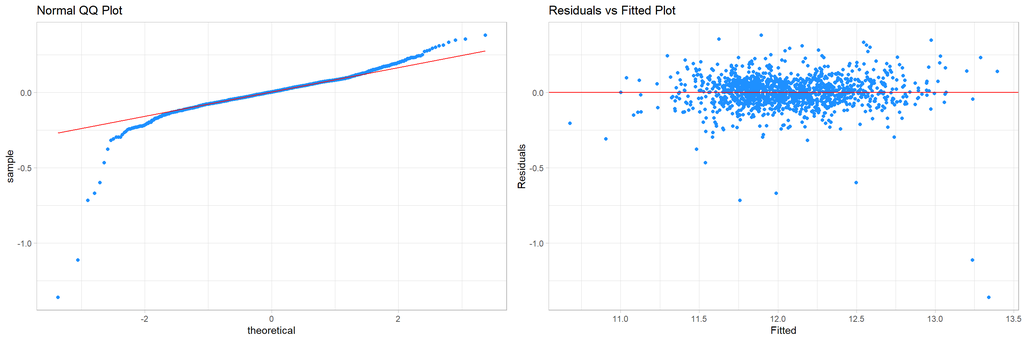

```
## $num_predictors
## [1] 41
##
## $shapiro_Normalcy_test_pvalue
## [1] 2.585324e-34
##
## $bptest_Const_Variance_test_pvalue
## [1] 1.562809e-38
##
## $RMSE
## [1] 0.1085
##
## $AdjustedR2
## [1] 0.9076311
##
## $AIC
## [1] -5668.259
```

```r
diagnostics(m_transform_1_step)
```

Looking at the diagnostics, our model can still do better. We will now look at the individual significant of the parameters of this model to see if we can eliminate any predictors

```r
a <- coef(summary(m_transform_1_step))[,"Pr(>|t|)"]
```

We will be conservative and use alpha = .1 We now identify the individual columns that have p-value of greater than .1 and remove them from the dataset to create another model

```r
names(a[a>.1])
```

```
##  [1] "LotShapeIR2"          "LotShapeReg"          "LotConfigFR3"
##  [4] "LotConfigInside"      "LandSlopeMod"         "LandSlopeSev"
##  [7] "NeighborhoodBlueste"  "NeighborhoodBrkSide"  "NeighborhoodClearCr"
## [10] "NeighborhoodCrawfor"  "NeighborhoodIDOTRR"   "NeighborhoodNoRidge"
## [13] "NeighborhoodNPkVill"  "NeighborhoodNridgHt"  "NeighborhoodSomerst"
## [16] "NeighborhoodSWISU"    "NeighborhoodTimber"   "NeighborhoodVeenker"
## [19] "Condition1Feedr"      "Condition1PosA"       "Condition1PosN"
## [22] "Condition1RRAe"       "Condition1RRNe"       "Condition1RRNn"
## [25] "Exterior1stCBlock"    "Exterior1stHdBoard"   "Exterior1stImStucc"
## [28] "Exterior1stPlywood"   "Exterior1stStone"     "Exterior1stStucco"
## [31] "Exterior1stWd Sdng"   "Exterior1stWdShing"   "ExterCondFa"
## [34] "ExterCondGd"          "ExterCondTA"          "FoundationWood"
## [37] "BsmtExposureMn"       "BsmtExposureNo"       "BsmtFinType1BLQ"
## [40] "BsmtFinType1GLQ"      "BsmtFinType1LwQ"      "BsmtFinType1Rec"
## [43] "HeatingGrav"          "HeatingOthW"          "HeatingQCFa"
## [46] "HeatingQCPo"          "KitchenAbvGr"         "FunctionalMin1"
## [49] "FunctionalMin2"       "FunctionalMod"        "FunctionalTyp"
## [52] "PavedDriveP"          "PavedDriveY"          "EnclosedPorch"
## [55] "SaleTypeCon"          "SaleTypeConLI"        "SaleTypeConLw"
## [58] "SaleTypeCWD"          "SaleTypeOth"          "SaleTypeWD"
## [61] "SaleConditionFamily"  "SaleConditionPartial"
```

```r
remove_cols3 <- c("YearRemodAdd","ExterCond","PavedDrive", "EnclosedPorch", "BsmtFinType")

f <- formula(m_transform_1_step)
predictor_list <- str_split(f, pattern = fixed(" + "))[[3]]
predictor_list <- predictor_list[!(predictor_list %in% remove_cols3)]
# replacing the \n that str_spit introduces after 500 characters
predictor_list <- str_replace(predictor_list, "\n    ", "")
# create the formula
(frm1 <- paste("log(SalePrice) ~ ", paste(predictor_list, collapse = ' + ')))
```

```
## [1] "log(SalePrice) ~  MSSubClass + MSZoning + LotShape + LandContour + LotConfig + LandSlope + Neighborhood + Condition1 + OverallQual + OverallCond + YearBuilt + Exterior1st + Foundation + BsmtQual + BsmtExposure + BsmtFinType1 + Heating + HeatingQC + CentralAir + X1stFlrSF + X2ndFlrSF + BsmtFu…
```

Now we use the above formula to create the model and look at its diagnostics

```r
m_transform_1_step_sig_only <- lm(frm1, data = df_cols_removed)
```

We do an anova test between the two models to make sure we have not discarded significant predictors

```r
anova(m_transform_1_step_sig_only, m_transform_1_step)
```

```
## Analysis of Variance Table
##
## Model 1: log(SalePrice) ~ MSSubClass + MSZoning + LotShape + LandContour +
##     LotConfig + LandSlope + Neighborhood + Condition1 + OverallQual +
##     OverallCond + YearBuilt + Exterior1st + Foundation + BsmtQual +
##     BsmtExposure + BsmtFinType1 + Heating + HeatingQC + CentralAir +
##     X1stFlrSF + X2ndFlrSF + BsmtFullBath + FullBath + HalfBath +
##     BedroomAbvGr + KitchenAbvGr + KitchenQual + Functional +
##     Fireplaces + GarageQual + GarageCond + WoodDeckSF + ScreenPorch +
##     SaleType + SaleCondition + log(LotArea) + log(GarageArea)
## Model 2: log(SalePrice) ~ MSSubClass + MSZoning + LotShape + LandContour +
##     LotConfig + LandSlope + Neighborhood + Condition1 + OverallQual +
##     OverallCond + YearBuilt + YearRemodAdd + Exterior1st + ExterCond +
##     Foundation + BsmtQual + BsmtExposure + BsmtFinType1 + Heating +
##     HeatingQC + CentralAir + X1stFlrSF + X2ndFlrSF + BsmtFullBath +
##     FullBath + HalfBath + BedroomAbvGr + KitchenAbvGr + KitchenQual +
##     Functional + Fireplaces + GarageQual + GarageCond + PavedDrive +
##     WoodDeckSF + EnclosedPorch + ScreenPorch + SaleType + SaleCondition +
##     log(LotArea) + log(GarageArea)
##   Res.Df    RSS Df Sum of Sq      F  Pr(>F)
## 1   1207 15.984
## 2   1200 15.741  7   0.24236 2.6394 0.01039 *
## ---
## Signif. codes:  0 '***' 0.001 '**' 0.01 '*' 0.05 '.' 0.1 ' ' 1
```

Now we will compare the diagnostics of the 2 models

```r
m_transform_1_step_result <- diagnostics(m_transform_1_step, plotit = FALSE)
m_transform_1_step_sig_only_result <- diagnostics(m_transform_1_step_sig_only, plotit = FALSE)

df_result <- rbind(m_transform_1_step=m_transform_1_step_result, m_transform_1_step_sig_only=m_transform_1_step_sig_only_result)

knitr::kable(df_result)
```

|  | num_predictors | shapiro_Normalcy_test_pvalue | bptest_Const_Variance_test_pvalue | RMSE | AdjustedR2 | AIC |
| --- | --- | --- | --- | --- | --- | --- |
| m_transform_1_step | 41 | 2.58532434377342e-34 | 1.56280913290727e-38 | 0.1085 | 0.907631103431557 | -5668.25929379707 |
| m_transform_1_step_sig_only | 37 | 4.37061579785164e-34 | 8.2169301822451e-41 | 0.1093 | 0.906752877081228 | -5661.81561020389 |

we will now look at the diagnostics plots for this model

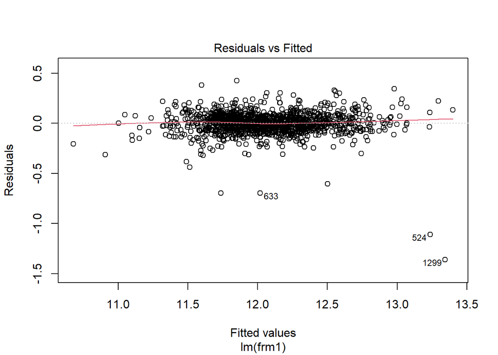

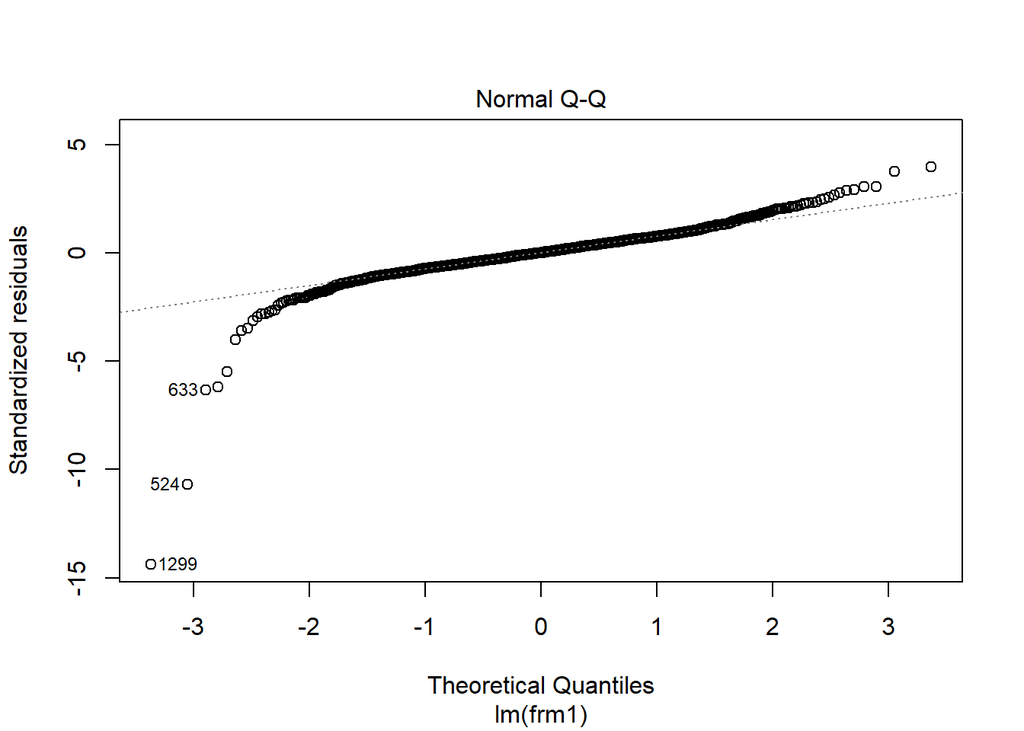

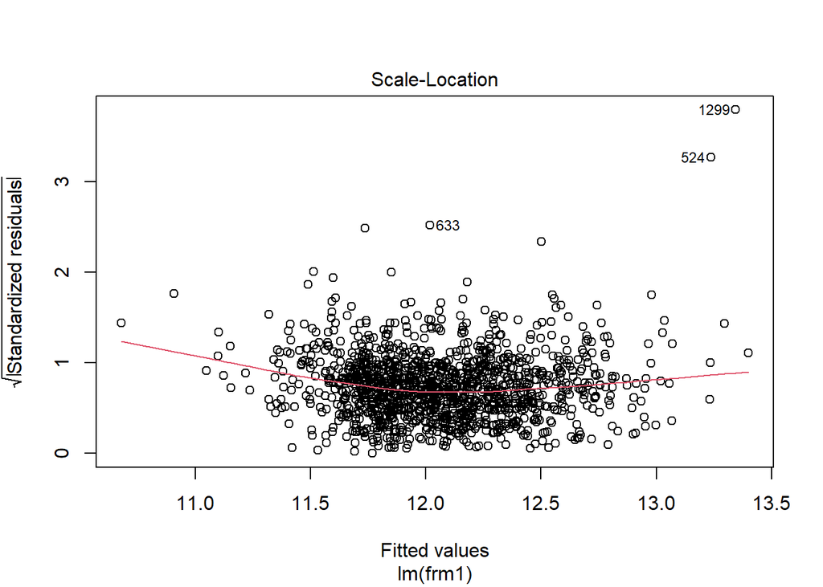

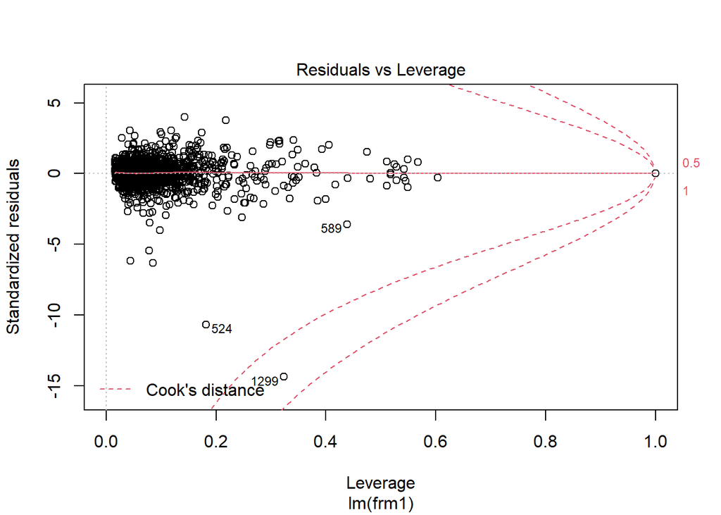

```r
plot(m_transform_1_step_sig_only)
```

We look at variance inflation factors, and filter by only vifs that are >5

```r
faraway::vif(m_transform_1_step_sig_only)[faraway::vif(m_transform_1_step_sig_only)>5]
```

```
##           MSZoningFV           MSZoningRL           MSZoningRM
##            16.951121            46.304868            30.796731
##  NeighborhoodBrkSide  NeighborhoodCollgCr  NeighborhoodCrawfor
##             6.555110            11.190361             5.942716
##  NeighborhoodEdwards  NeighborhoodGilbert   NeighborhoodIDOTRR
##             7.019645             7.278823             5.593370
##    NeighborhoodNAmes  NeighborhoodNridgHt   NeighborhoodNWAmes
##            17.587236             6.332576             7.423773
##  NeighborhoodOldTown   NeighborhoodSawyer  NeighborhoodSawyerW
##            13.850877             7.276555             5.324532
##  NeighborhoodSomerst            YearBuilt   Exterior1stCemntBd
##            10.264811            12.185867             6.075455
##   Exterior1stHdBoard   Exterior1stMetalSd   Exterior1stPlywood
##            16.911965            15.568023             9.594118
##   Exterior1stVinylSd   Exterior1stWd Sdng     FoundationCBlock
##            28.365722            14.420805             7.164986
##      FoundationPConc           BsmtQualGd           BsmtQualTA
##             8.360265             6.207361             9.867833
##            X2ndFlrSF        KitchenQualGd        KitchenQualTA
##             5.579018             6.649901             8.842501
##        FunctionalTyp         GarageQualFa         GarageQualGd
##             9.189799            55.405873            17.197621
##         GarageQualPo         GarageQualTA         GarageCondFa
##             5.768295            75.730585            56.169150
##         GarageCondGd         GarageCondPo         GarageCondTA
##            16.322905            14.504310            83.417516
##          SaleTypeNew           SaleTypeWD SaleConditionPartial
##            46.188707             5.129151            44.139760
```

We will now look at high influence points and investigate them

```r
(influentials <- which(cooks.distance(m_transform_1_step_sig_only) > (4 / length(cooks.distance(m_transform_1_step_sig_only)))))
```

```
##   31   54   67   94  108  143  176  182  189  198  218  238  247  254  272  314
##   30   51   64   87   99  130  158  164  170  179  197  216  224  230  247  286
##  319  327  329  384  407  412  439  440  455  457  463  470  480  489  524  547
##  291  299  301  351  371  376  401  402  416  418  424  430  440  449  482  500
##  558  561  584  589  590  608  629  633  665  667  677  682  689  712  715  727
##  510  513  534  539  540  558  576  580  606  608  618  623  630  651  654  666
##  729  748  763  775  790  810  812  813  873  875  886  899  913  917  936  945
##  668  685  698  710  723  743  745  746  803  805  816  827  841  845  863  870
##  998 1007 1063 1093 1108 1123 1128 1133 1140 1159 1169 1181 1182 1183 1185 1212
##  914  922  970  999 1013 1028 1032 1036 1042 1060 1070 1080 1081 1082 1084 1111
## 1265 1267 1268 1271 1293 1299 1313 1325 1384 1388 1394 1424 1431 1433 1444
## 1157 1159 1160 1163 1183 1189 1203 1213 1267 1271 1277 1305 1312 1314 1325
```

As an experiment we try and remove the influentials and see what impact this has on the diagnostics

```r
df_wo_influentials <- df_cols_removed[-influentials,]
df_only_influentials <- df_cols_removed[influentials,]

m_no_influentials <- lm(formula(m_transform_1_step_sig_only), data = df_wo_influentials)
```

```r
m_transform_1_step_sig_only_result <- diagnostics(m_transform_1_step_sig_only, plotit = FALSE)
m_no_influentials_result <- diagnostics(m_no_influentials, plotit = FALSE)

df_result <- rbind(m_transform_1_step_sig_only=m_transform_1_step_sig_only_result , m_no_influentials=m_no_influentials_result)

knitr::kable(df_result)
```

|  | num_predictors | shapiro_Normalcy_test_pvalue | bptest_Const_Variance_test_pvalue | RMSE | AdjustedR2 | AIC |
| --- | --- | --- | --- | --- | --- | --- |
| m_transform_1_step_sig_only | 37 | 4.37061579785164e-34 | 8.2169301822451e-41 | 0.1093 | 0.906752877081228 | -5661.81561020389 |
| m_no_influentials | 37 | 0.00105949872525489 | 0.00497557312769214 | 0.0691 | 0.958804107246139 | -6389.94189323825 |

Hence now our good model is m_no_influentials and the dataset is df_wo_influentials

```r
m_small <- lm("log(SalePrice)~OverallCond", data = df_wo_influentials)

m_small_step <- step(m_small, scope = formula(m_no_influentials), direction = "forward", trace = 0)
```

We will now look at diagnostics data with these two models

```r
m_no_influentials_result <- diagnostics(m_no_influentials, plotit = FALSE)
m_small_step_result <- diagnostics(m_small_step, plotit = FALSE)

df_result <- rbind(m_no_influentials=m_no_influentials_result, m_small_step=m_small_step_result)

knitr::kable(df_result)
```

|  | num_predictors | shapiro_Normalcy_test_pvalue | bptest_Const_Variance_test_pvalue | RMSE | AdjustedR2 | AIC |
| --- | --- | --- | --- | --- | --- | --- |
| m_no_influentials | 37 | 0.00105949872525489 | 0.00497557312769214 | 0.0691 | 0.958804107246139 | -6389.94189323825 |
| m_small_step | 34 | 0.000990877919450283 | 0.00272976884555727 | 0.0694 | 0.958751490269576 | -6397.26691137094 |

Most of the diagnostics are the same

To decide we will look at the anova test

```r
anova(m_small_step, m_no_influentials)
```

```
## Analysis of Variance Table
##
## Model 1: log(SalePrice) ~ OverallCond + OverallQual + log(LotArea) + Neighborhood +
##     X1stFlrSF + X2ndFlrSF + YearBuilt + BsmtFullBath + Exterior1st +
##     KitchenAbvGr + KitchenQual + Functional + BsmtExposure +
##     SaleCondition + Condition1 + log(GarageArea) + ScreenPorch +
##     BsmtFinType1 + MSZoning + CentralAir + BsmtQual + Fireplaces +
##     MSSubClass + Heating + Foundation + GarageQual + GarageCond +
##     WoodDeckSF + LotConfig + LotShape + HeatingQC + HalfBath +
##     FullBath + LandSlope
## Model 2: log(SalePrice) ~ MSSubClass + MSZoning + LotShape + LandContour +
##     LotConfig + LandSlope + Neighborhood + Condition1 + OverallQual +
##     OverallCond + YearBuilt + Exterior1st + Foundation + BsmtQual +
##     BsmtExposure + BsmtFinType1 + Heating + HeatingQC + CentralAir +
##     X1stFlrSF + X2ndFlrSF + BsmtFullBath + FullBath + HalfBath +
##     BedroomAbvGr + KitchenAbvGr + KitchenQual + Functional +
##     Fireplaces + GarageQual + GarageCond + WoodDeckSF + ScreenPorch +
##     SaleType + SaleCondition + log(LotArea) + log(GarageArea)
##   Res.Df    RSS Df Sum of Sq      F Pr(>F)
## 1   1126 5.9918
## 2   1116 5.9310 10  0.060789 1.1438 0.3257
```

With most of the diagnostics being the same and the pvalue of anova test being fairly large, and the number of predictors being slightly less for the smaller model, we will use m_small_step our final model.

We look at the diagnostics plot finally

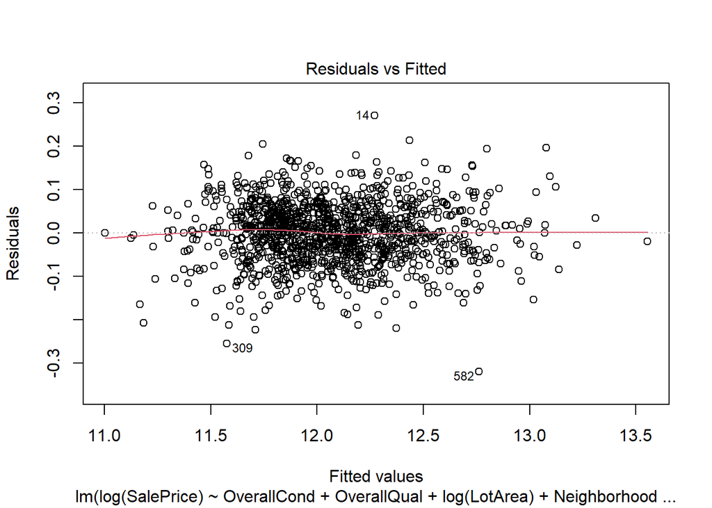

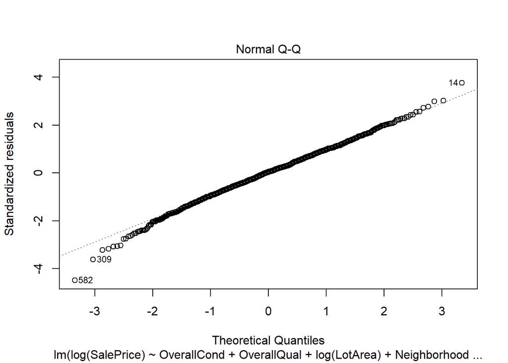

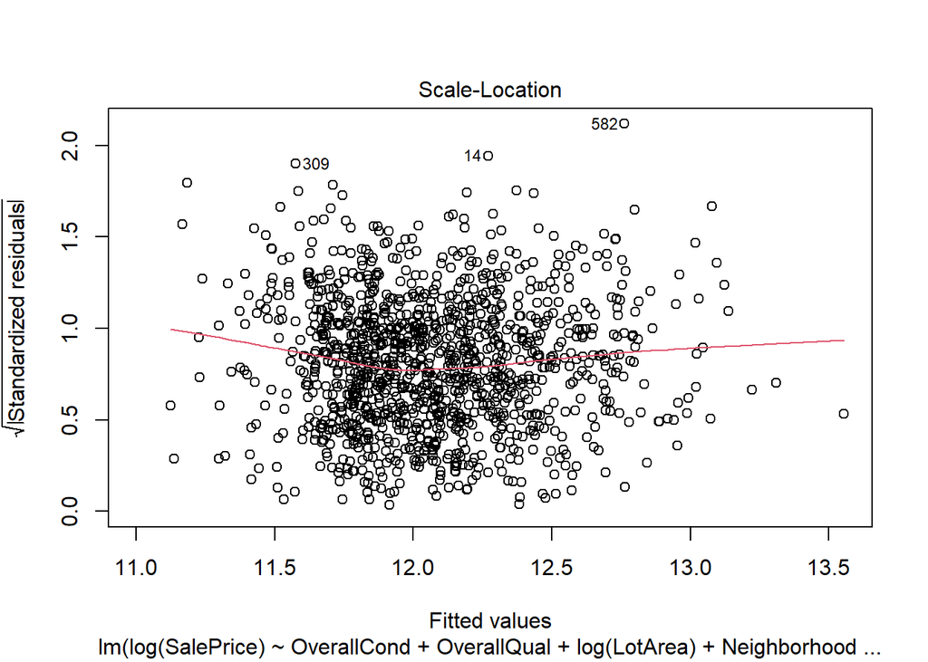

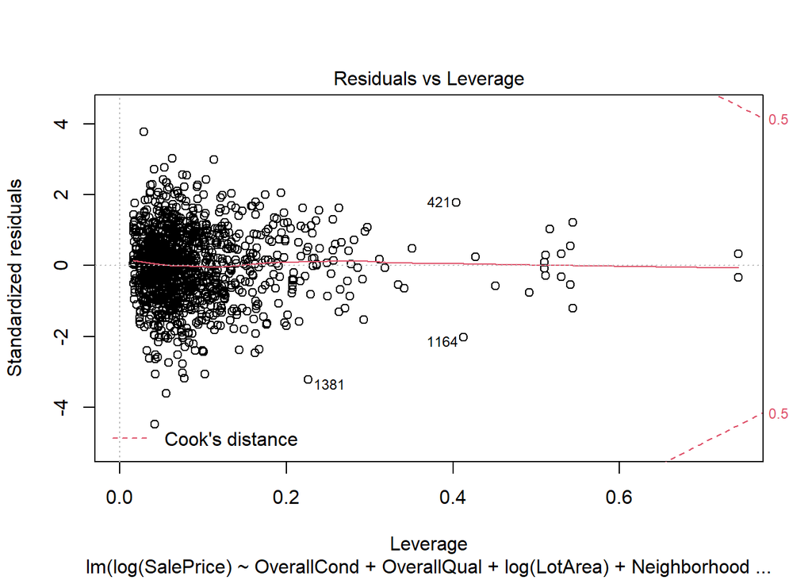

```r
plot(m_small_step)
```

Our diagnostics plots look fairly ok. We know that our shapiro test and BP test are rejecting the null hypothesis, but since the graphs looks pretty good, and we know that these tests are quick to reject for large datasets, we will move ahead with this model